# Advanced Topics in Data Science

COS 2019

Phil Chodrow

January 17th, 2019

# Good Morning

## Some Draft Session Titles

- Don’t Write For Loops
- Stupid Data Frame Tricks
- Stupid Data Frame *Methods*
- *“Advanced Topics in Data Science”* (“I Give Up On Descriptive Names”)

So, uh, what are we actually doing here?

## In Previous Sessions, We’ve Done:

- Import $\rightarrow$ tidy $\rightarrow$ transform
- Import $\rightarrow$ tidy $\rightarrow$ transform $\rightarrow$ model
- Import $\rightarrow$ tidy $\rightarrow$ transform $\rightarrow$ visualize

## Gameplan for Today

- Work through an extended example of the **data-scientific method.**
- Learn how to construct **complex data pipelines** efficiently and elegantly.
- And, most importantly…

## Impress Jean-Luc Picard

[figure not shown]

## Exercise 0.0

1. Open `case_study_student.R` in `R`. You may use `case_study_complete.R` for troubleshooting if needed.
2. Session $->$ Set Working Directory $->$ To Source File Location.

## Exercise 0.1

1. Look left.
2. Look right.
3. Pick a partner (groups of three are fine).
4. Give them a friendly, professional smile.
5. Maybe a handshake too.

[figure not shown]

# Case Study, Part 1

## For Loops

```r
names <- list.files('data/prices', full.names = T)

prices <- data_frame()
for(name in names){
  df <- read_csv(name)
  prices <- rbind(df, prices)
}
prices
```

## For Loops

```r
letters <- c('A', 'B', 'C', 'D', 'E')

starships <- c()
for(letter in letters){
  ship_name <- paste('U.S.S. Enterprise', letter)
  starships <- c(starships, ship_name)
}
starships # now this is what I want
```

```
## [1] "U.S.S. Enterprise A" "U.S.S. Enterprise B" "U.S.S. Enterprise C"
## [4] "U.S.S. Enterprise D" "U.S.S. Enterprise E"
```

## Towards Map

Note that this works too:

```r
paste('U.S.S. Enterprise', letters)
```

```
## [1] "U.S.S. Enterprise A" "U.S.S. Enterprise B" "U.S.S. Enterprise C"
## [4] "U.S.S. Enterprise D" "U.S.S. Enterprise E"
```

That’s because `paste()` is a *vectorized function*.

What if we could…

[figure not shown]

## `map()`

If $X = (x_1,\ldots,x_n)$, then

> `map(X, f)` = $(f(x_1),\ldots,f(x_n))$

> `map()` is imported as part of the `purrr` package, which is itself part of the `tidyverse()` meta-package.

## What do these do?

```r
c('To', 'boldly', 'go') %>% map(nchar)

c('To', 'boldly', 'go') %>% map(toupper)

c('To', 'boldly', 'go') %>% map(rep, 2)
```

## `Reduce()` Combines

If $g$ is a binary function, then

`reduce(X, g)` = $g(...(g(g(x_1,x_2),x_3),...,x_n)$

## What do these do?

```r
c('To', 'boldly', 'go') %>% map(nchar) %>% reduce(sum)

c('To', 'boldly', 'go') %>% reduce(paste)
```

# Case Study, Part 2

## What We’d Like to Do

[figure not shown]

## A For Loop?…

```r
model_container <- ????
for(id in unique(prices$listing_id)){
    model <- prices %>%
        filter(listing_id == id) %>%
        loess(price_per ~ as.numeric(date),
              data = .,
              span = .25)

    model_container %>% update(model) # ?????
    .
    .
    .
}
```

## A For Loop?…

[figure not shown]

## Anyone Have a Better Idea?

## Assembling the Pieces

- `map` operates on lists…
- Models like `loess` operate on `data_frames`…

## Well if you love lists and data frames so much…

[figure not shown]

## That’s a good idea!

```r
prices_nested <- prices %>%
    tidyr::nest(-listing_id)

# view the data types of the columns
map(prices_nested, class) %>% unlist()
```

```
## listing_id       data
##  "numeric"     "list"
```

## Ew.

[figure not shown]

## Actually…

```r
prices_nested %>% head()
```

```
## # A tibble: 6 x 2
##   listing_id data
##        <dbl> <list>
## 1    3075044 <tibble [359 × 2]>
## 2       6976 <tibble [319 × 2]>
## 3    7651065 <tibble [334 × 2]>
## 4    5706985 <tibble [344 × 2]>
## 5    2843445 <tibble [365 × 2]>
## 6     753446 <tibble [347 × 2]>
```

## WELP

[figure not shown]

## Just checking

```r
prices_nested$data[[1]] # get the first item of the list
```

```
## # A tibble: 359 x 2
##    date       price_per
##    <date>         <dbl>
##  1 2017-04-30      32.5
##  2 2017-04-29      37.5
##  3 2017-04-28      37.5
##  4 2017-04-27      32.5
##  5 2017-04-26      32.5
##  6 2017-04-25      32.5
##  7 2017-04-24      32.5
##  8 2017-04-23      32.5
##  9 2017-04-22      37.5
## 10 2017-04-21      37.5
## # … with 349 more rows
```

## We were here:

[figure not shown]

## Now we’re here:

[figure not shown]

# Case Study, Part 3

## Thousands of Models in 5 Lines

```r
prices_modeled <- prices %>%
  nest(-listing_id) %>%
  mutate(model = map(data,
                     ~loess(price_per ~ as.numeric(date),
                            data = .,
                            span = .25)),
         preds = map2(model, data, augment)) %>%
  unnest(preds)
```

## We were here:

[figure not shown]

## Then we did this:

[figure not shown]

## Now we’re here:

[figure not shown]

## All in 5 Lines

[figure not shown]

## Next Turn: Separate Out The Spikes

## Tool: K-Means

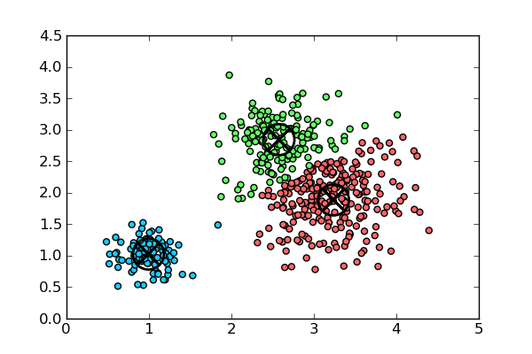

# Case Study, Part 4

# Wrapping Up

## What We’ve Done

1. Noticed something interesting in a relevant data set.
2. Posed a hypothesis to explain that interesting thing.
3. Tested our hypothesis using an iterative and cyclical data analytical process.

[figure not shown]

## Learn More

- [Functional programming](https://purrr.tidyverse.org/) with `purrr` (`map()` and friends) – read the docs!
- Jenny Bryan’s [excellent purrr tutorial](https://jennybc.github.io/purrr-tutorial/).
- [*R for Data Science*](https://r4ds.had.co.nz/), an excellent (and free!) book on how to become a tidy warrior.
- [*Advanced R*](http://adv-r.had.co.nz/), for those of you who want to go even deeper.
- [R Markdown](https://rmarkdown.rstudio.com/) is the best way to communicate in and about `R` – learn more and use it in all your `R` projects!

[figure not shown]